# exercise 4

```r
##Practical 4
##Script 4-3
##Bi-temporal change detection
###The parts of the script you need to fill or complement are marked with **

##**Load raster package
library(raster)

##**Clear (environment
rm(list=ls())

##**Set the workspace for the folder where your NDVI imagery are located
setwd("C:/Users/oyelo/Desktop/advanced remote sensing/practical 4/Material_and_Scripts_P4/Task_1_2_and_3_MODIS_monthly_NDVI")
getwd()
```

```
## [1] "C:/Users/oyelo/Desktop/advanced remote sensing/practical 4/Material_and_Scripts_P4/Task_1_2_and_3_MODIS_monthly_NDVI"
```

```r
##**create a list of all NDVI images for the year 2009 (use the "list.files" function)
ndvi2009 = list.files(pattern="*_2009_*")
ndvi2009
```

```
##  [1] "MOD13Q1_Taita_2009_1.tif"  "MOD13Q1_Taita_2009_10.tif"
##  [3] "MOD13Q1_Taita_2009_11.tif" "MOD13Q1_Taita_2009_12.tif"
##  [5] "MOD13Q1_Taita_2009_2.tif"  "MOD13Q1_Taita_2009_3.tif"
##  [7] "MOD13Q1_Taita_2009_4.tif"  "MOD13Q1_Taita_2009_5.tif"
##  [9] "MOD13Q1_Taita_2009_6.tif"  "MOD13Q1_Taita_2009_7.tif"
## [11] "MOD13Q1_Taita_2009_8.tif"  "MOD13Q1_Taita_2009_9.tif"
```

```r
##**create a list of all NDVI images for the year 2013 (use the "list.files" function)
ndvi2013=list.files(pattern="*_2013_*")
ndvi2013
```

```
##  [1] "MOD13Q1_Taita_2013_1.tif"  "MOD13Q1_Taita_2013_10.tif"
##  [3] "MOD13Q1_Taita_2013_11.tif" "MOD13Q1_Taita_2013_12.tif"
##  [5] "MOD13Q1_Taita_2013_2.tif"  "MOD13Q1_Taita_2013_3.tif"
##  [7] "MOD13Q1_Taita_2013_4.tif"  "MOD13Q1_Taita_2013_5.tif"
##  [9] "MOD13Q1_Taita_2013_6.tif"  "MOD13Q1_Taita_2013_7.tif"
## [11] "MOD13Q1_Taita_2013_8.tif"  "MOD13Q1_Taita_2013_9.tif"
```

```r
##**read all 2009 imagery using the "stack" function
ndvi.stack2009<-stack(ndvi2009)
##**read all 2013 imagery using the "stack" function
ndvi.stack2013<-stack(ndvi2013)

##**calculate the average of all 2009 ndvi images, using the "calc" function
mean.NDVI2009<- calc(ndvi.stack2009, fun=mean)

##**calculate the average of all 2013 ndvi images, using the "calc" function
mean.NDVI2013<- calc(ndvi.stack2013, fun=mean)

mean.NDVI2009<-mean.NDVI2009/10000
mean.NDVI2013<-mean.NDVI2013/10000

#**Take a look at your results using plot function
#par(mfrow = c(1, 2))
#plot(mean.NDVI2009)

#plot(mean.NDVI2013)

##**perform a image rationing analysis using the 2009 and 2013 mean ndvi imagery
r09.13<-mean.NDVI2009/mean.NDVI2013
r09.13
```

```
## class       : RasterLayer
## dimensions  : 234, 284, 66456  (nrow, ncol, ncell)
## resolution  : 250, 250  (x, y)
## extent      : 405744.7, 476744.7, -407114.1, -348614.1  (xmin, xmax, ymin, ymax)
## coord. ref. : +proj=utm +zone=37 +datum=WGS84 +units=m +no_defs +ellps=WGS84 +towgs84=0,0,0
## data source : in memory
## names       : layer
## values      : 0.5141357, 1.573047  (min, max)
```

```r
##**perform a image differencing analysis using the 2009 and 2013 mean ndvi imagery
d09.13<- mean.NDVI2009-mean.NDVI2013
d09.13
```

```
## class       : RasterLayer
## dimensions  : 234, 284, 66456  (nrow, ncol, ncell)
## resolution  : 250, 250  (x, y)
## extent      : 405744.7, 476744.7, -407114.1, -348614.1  (xmin, xmax, ymin, ymax)
## coord. ref. : +proj=utm +zone=37 +datum=WGS84 +units=m +no_defs +ellps=WGS84 +towgs84=0,0,0
## data source : in memory
## names       : layer
## values      : -0.2384167, 0.2003333  (min, max)
```

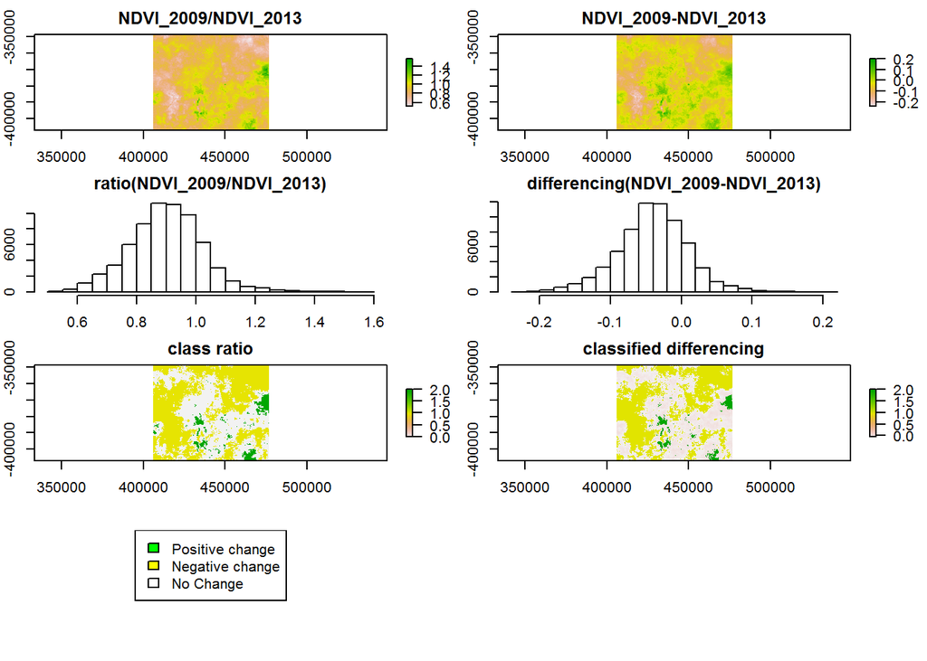

```r
par(mar = c(2, 2, 2, 2), mfrow=c(4,2))
#image of rationing
plot(r09.13, main="NDVI_2009/NDVI_2013")

#image of differencing
plot(d09.13, main="NDVI_2009-NDVI_2013")

##**plot the histogram of the ratio image
hist(r09.13, main="ratio(NDVI_2009/NDVI_2013)")

##**Plot the histogram of the differencing image
hist(d09.13, main="differencing(NDVI_2009-NDVI_2013)")

##Classify the ratio and differencing image using thresholds obtained from a visual inspection of the histograms
class.ratio=r09.13
class.ratio[r09.13>0.9 & r09.13<1.1] <- 0 #0 represents no significant change
class.ratio[r09.13<0.9] <- 1 #1represents negative change
class.ratio[r09.13>1.1] <- 2  #2represents positive change
#plot(class.ratio, main="class ratio", legend = T)
#hist(class.ratio, main="class ratio")


class.diff=d09.13
class.diff[d09.13>(-0.05) & r09.13<0.05] <- 0 #0 represents no significant change
class.diff[d09.13<(-0.05)] <- 1 #1represents negative change
class.diff[d09.13> 0.05 ]<- 2  #2represents positive change
#hist(class.ratio, main="class ratio")
#hist(class.diff, main="classified differencing")
plot(class.ratio, main="class ratio", legend = T)
plot(class.diff, main="classified differencing", legend = T)
plot.new()
legend("top", legend = c("Positive change", "Negative change", "No Change"), bty = c(1,1), fill = c("green" ,"yellow", "white"), cex= 1)

# PLOTS
#par(mar = c(1, 1, 1, 1),mfrow=c(3,1))
#plot(class.ratio, legend = T)
#plot(class.diff, legend = T)
#plot.new()
#legend("top", legend = c("Positive change", "Negative change", "No Change"), bty = c(1,1), fill = c("green" ,"yellow", "white"), cex= 1)


##Classification example##

#Let's say that "im.ratio" is the result of my image rationing analysis and "class.ratio" is the classified image (that still doesn't exist)
#class.ratio=im.ratio #first create "class.ratio" as an exact copy of im.ratio
#class.ratio[im.ratio>0.9 & im.ratio<1.1] <- 1 #where the values in im.ration are between 0.9 and 1.1, the values of class.ratio is set to 1
```

```r
###Practical 4#######
###Script 4-4
###Perform change vector analysis and plot polar histogram
###The parts of the script you need to fill or complement are marked with **

##**Install and load the plotrix package
#install.packages("plotrix")
library(plotrix)
##** load the raster and maptools packages
#library(raster)
#library(maptools)

##**Clear environment
rm(list = ls())

##**set the work space for the folder where you saved the MODIS red and NIR band files
setwd("C:/Users/oyelo/Desktop/advanced remote sensing/practical 4/Material_and_Scripts_P4/Tasks_4_MODIS_red_NIR")
getwd()
```

```
## [1] "C:/Users/oyelo/Desktop/advanced remote sensing/practical 4/Material_and_Scripts_P4/Tasks_4_MODIS_red_NIR"
```

[figure not shown]

```r
##**read red band from September 2013
red.date1<-raster("MOD13Q1.2013241.red.UTM_Taita.tif")

##**read red band from December 2013
red.date2<-raster("MOD13Q1.2013353.red.UTM_Taita.tif")

##**read NIR band from September 2013
nir.date1<-raster("MOD13Q1.2013241.NIR.UTM_Taita.tif")

##**read NIR band from December 2013
nir.date2<-raster("MOD13Q1.2013353.NIR.UTM_Taita.tif")

##The following lines calculate the change angles
##To understand the change angle calculation, refer to the equations in the lecture material
delta.NIR=nir.date2-nir.date1 #Calculated NIR difference between September and December
delta.red=red.date2-red.date1 #Calculated red difference between September and December
alfa=atan((delta.red)/(delta.NIR)) #Calculate the change angle

alfa=(alfa*180)/pi #Convert change angle from radian to degrees

###The following code convert the angle values to a 0 to 360 degrees range### see lecture material
alfa[delta.NIR<0 & delta.red>0]<-(alfa+180)[delta.NIR<0 & delta.red>0]
alfa[delta.NIR<0 & delta.red<0]<-(alfa+180)[delta.NIR<0 & delta.red<0]
alfa[delta.NIR>0 & delta.red<0]<-(alfa+360)[delta.NIR>0 & delta.red<0]
alfa[delta.NIR==0 & delta.red!=0]<-270

#plot(alfa, main="change in angle image")#visualize the change angle image

intervals=seq(0, 360, by=5)#create a vector describing the intervals of the histogram
#First I create a normal histogram, with the intervals between 0 to 360 and the bars width equal to 5
#(we just need this to obtain the count of each angle value.. so you don't need to present this normal histogram in your report)
```

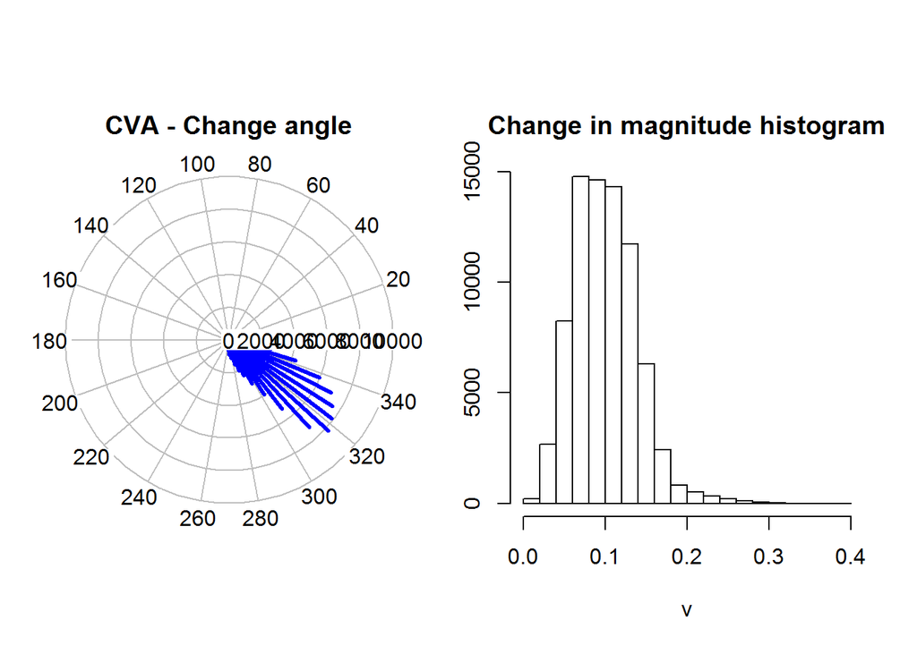

```r
frequency<-h$counts #counts the frequency of each angle
angle<-h$mids #gets the angle values

par(mfrow=c(1,2))
polar.plot(frequency,angle, main="CVA - Change angle",lwd=3,line.col=4) #Plot a polar histogram

#plot(frequency)
##**Calculate the change magnitude

change.mag<-sqrt((delta.red^2)+(delta.NIR^2))
hist(change.mag, main="Change in magnitude histogram")
```

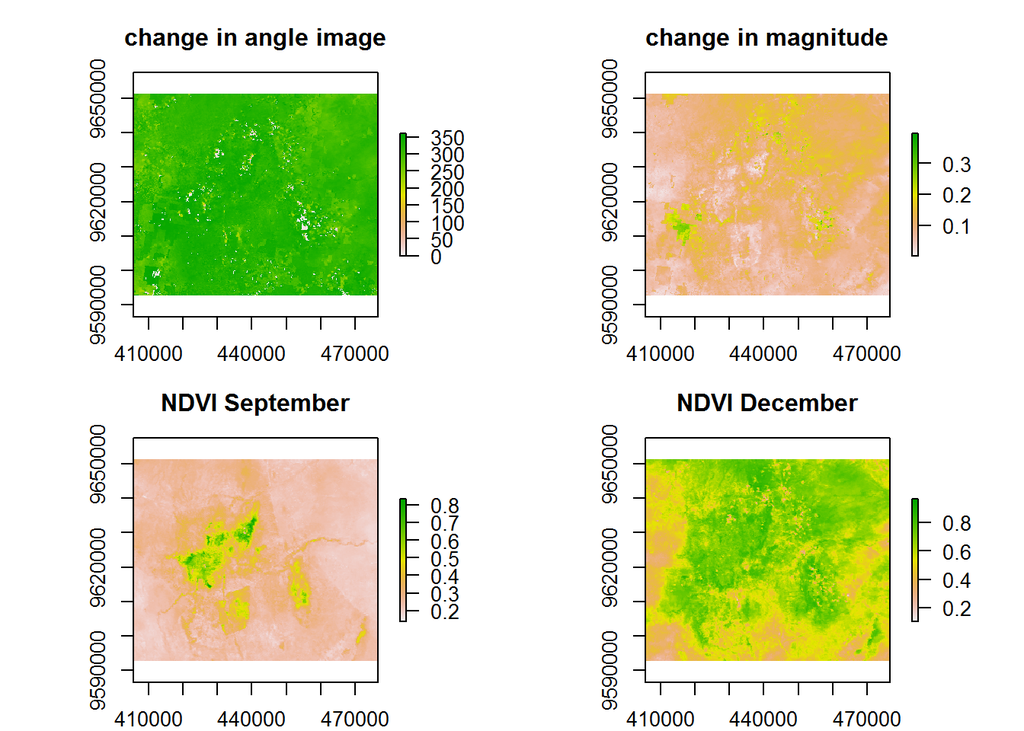

```r
par(mfrow=c(2,2))
#plot change angle image(from 0 to 360)
plot(alfa, main="change in angle image")#visualize the change angle image

##**Plot the histogram of the change magnitude
plot(change.mag, main="change in magnitude")


##**Calculate the NDVI for the September image
ndvi.sept<-(nir.date1-red.date1)/(nir.date1+red.date1)
plot(ndvi.sept, main="NDVI September")
##**Calculate the NDVI for the December image
ndvi.dec<-(nir.date2-red.date2)/(nir.date2+red.date2)
plot(ndvi.dec, main="NDVI December")
```

The average change angle is 313.1595 degree while the average change magnitude is 0.1001708. This can be seen below:

```r
mean(alfa[alfa])
```

```
## [1] 313.1595
```

```r
mean(change.mag[change.mag])
```

```
## [1] 0.1001708
```

Mainly just one kind of change can be identified from the CVA plot. It only shows differing magnitue but the angles of the bars are titled towards increasing greeness(+NIR) and decreasing brightness(-RED). This can also be seen from the averge angle of 313 degree. This can be due to the seasonal change from dry to wet when the vegetation is healthy, denser and greener.

The dominant land change that can be seen is the vegetation getting denser and greener.